# 의학통계방법론 1조 CH24 과제

김재혁, 정지현

2022-06-09

```r
getwd()
```

```
## [1] "C:/git_blog/study/data/ch12"
```

```r
library(readxl)
library(dplyr)
library(kableExtra)
library(broom)
library(ggplot2)
library(agricolae)
library(nonpar)
```

**엑셀파일불러오기**

```r
#모든 시트를 하나의 리스트로 불러오는 함수
read_excel_allsheets <- function(file, tibble = FALSE) {
  sheets <- readxl::excel_sheets(file)
  x <- lapply(sheets, function(X) readxl::read_excel(file, sheet = X))
  if(!tibble) x <- lapply(x, as.data.frame)
  names(x) <- sheets
  x
}
```

## 0.1 12장

**12장 연습문제 불러오기**

```r
#data_chap12에 연습문제 12장 모든 문제 저장
data_chap12 <- read_excel_allsheets("data_chap12.xls")

#연습문제 각각 데이터 생성
for (x in 1:length(data_chap12)){
  assign(paste0('ex12_',c(1,4,5,6))[x],data_chap12[x])
  }

#연습문제 데이터 형식을 리스트에서 데이터프레임으로 변환
for (x in 1:length(data_chap12)){
  assign(paste0('ex12_',c(1,4,5,6))[x],data.frame(data_chap12[x]))
  }
```

## 0.2 EXAMPLE 12.1

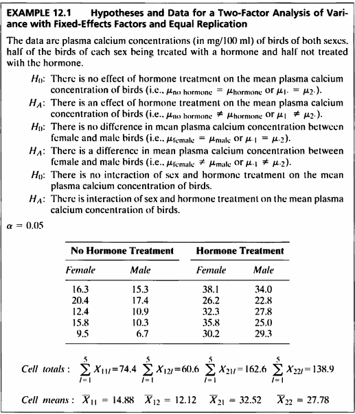

```r
#데이터셋
ex12_1%>%
  kbl(caption = "Dataset",escape=F) %>%
  kable_styling(bootstrap_options = c("striped", "hover", "condensed", "responsive"))
```

Dataset

| exam12_1.No | exam12_1.Hormone | exam12_1.Sex | exam12_1.plasma_calcium |
| --- | --- | --- | --- |
| 1 | No Hormone | Female | 16.3 |
| 2 | No Hormone | Female | 20.4 |
| 3 | No Hormone | Female | 12.4 |
| 4 | No Hormone | Female | 15.8 |
| 5 | No Hormone | Female | 9.5 |
| 6 | No Hormone | Male | 15.3 |
| 7 | No Hormone | Male | 17.4 |
| 8 | No Hormone | Male | 10.9 |
| 9 | No Hormone | Male | 10.3 |
| 10 | No Hormone | Male | 6.7 |
| 11 | Yes Hormone | Female | 38.1 |
| 12 | Yes Hormone | Female | 26.2 |
| 13 | Yes Hormone | Female | 32.3 |
| 14 | Yes Hormone | Female | 35.8 |
| 15 | Yes Hormone | Female | 30.2 |
| 16 | Yes Hormone | Male | 34.0 |
| 17 | Yes Hormone | Male | 22.8 |
| 18 | Yes Hormone | Male | 27.8 |
| 19 | Yes Hormone | Male | 25.0 |
| 20 | Yes Hormone | Male | 29.3 |

- 해당 데이터는 성별에 따른 새의 혈청 내 칼슘 농도를 기록한 데이터이다.
- 호르몬 치료 유무와 성별에 따른 혈청 내 칼슘 농도에 차이가 있는지 이요인 분산분석을 시행한다.

$$\begin{aligned}
H_0 &: There\ is\ no\ effect\ of\ hormone\ treatment\ on\ the\ mean\
plasma\ calcium\ concentration\ of\ birds\ \\
H_A &: There\ is\ an\ effect\ of\ hormone\ treatment\ on\ the\ mean\
plasma\ calcium\ concentration\ of\ birds\ \\
\\
H_0 &: There\ is\ no\ difference\ \ in\ mean\ plasma\ calcium\
concentration\ between\ female\ and\ male\ birds\ \\
H_A &: There\ is\ a\ difference\ \ in\ mean\ plasma\ calcium\
concentration\ between\ female\ and\ male\ birds\ \\
\\
H_0 &: There\ is\ no\ interaction\ of\ sex\ and\ hormone\ treatment\
on\ the\ mean\ plasma\ calcium\ concentration\ of\ birds\ \\
H_A &: There\ is\ interaction\ of\ sex\ and\ hormone\ treatment\ on\
the\ mean\ plasma\ calcium\ concentration\ of\ birds\ \\
\end{aligned}$$

```r
nf <- subset(ex12_1$exam12_1.plasma_calcium, ex12_1$exam12_1.Hormone=="No Hormone" & ex12_1$exam12_1.Sex=="Female")
nm <- subset(ex12_1$exam12_1.plasma_calcium, ex12_1$exam12_1.Hormone=="No Hormone" & ex12_1$exam12_1.Sex=="Male")
yf <- subset(ex12_1$exam12_1.plasma_calcium, ex12_1$exam12_1.Hormone=="Yes Hormone" & ex12_1$exam12_1.Sex=="Female")
ym <- subset(ex12_1$exam12_1.plasma_calcium, ex12_1$exam12_1.Hormone=="Yes Hormone" & ex12_1$exam12_1.Sex=="Male")
ex12_1a <- data.frame(no_hormone_female=nf,no_hormone_male=nm,yes_hormone_female=yf,yes_hormone_male=ym)
ex12_1a%>%
  kbl(caption = "Dataset of ex12_1") %>%
  kable_styling(bootstrap_options = c("striped", "hover", "condensed", "responsive"))
```

Dataset of ex12_1

| no_hormone_female | no_hormone_male | yes_hormone_female | yes_hormone_male |
| --- | --- | --- | --- |
| 16.3 | 15.3 | 38.1 | 34.0 |
| 20.4 | 17.4 | 26.2 | 22.8 |
| 12.4 | 10.9 | 32.3 | 27.8 |
| 15.8 | 10.3 | 35.8 | 25.0 |
| 9.5 | 6.7 | 30.2 | 29.3 |

```r
cell_totals <- c(sum(nf),sum(nm),sum(yf),sum(ym))
cell_means <- c(mean(nf),mean(nm),mean(yf),mean(ym))
cell <- data.frame(rbind(cell_totals,cell_means))
names(cell) <- c("X_11","X_12","X_21","X_22")
cell%>%
  kbl(caption = "Cell totals and Cell means") %>%
  kable_styling(bootstrap_options = c("striped", "hover", "condensed", "responsive"))
```

Cell totals and Cell means

|  | X_11 | X_12 | X_21 | X_22 |
| --- | --- | --- | --- | --- |
| cell_totals | 74.40 | 60.60 | 162.60 | 138.90 |
| cell_means | 14.88 | 12.12 | 32.52 | 27.78 |

## 0.3 EXAMPLE 12.1a

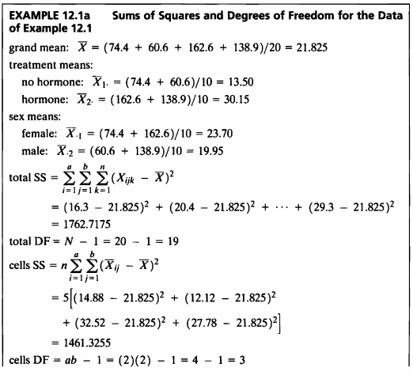

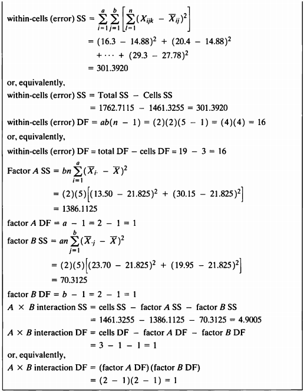

- 예제에서 나온 식으로 제곱합 및 자유도를 구하는 함수를 직접 작성하여 ANOVA table을 작성하여 보았다.

```r
f12_1a <- function(x){
  N <- (length(x)*nrow(x))
  grand_mean <- sum(x)/N
  no_hormone_means <- sum(x[,1:2])/10
  hormone_means <- sum(x[,3:4])/10
  female_means <- sum(x[,c(1,3)])/10
  male_means <- sum(x[,c(2,4)])/10
  total_SS <- sum((x-grand_mean)^2)
  total_DF <- N-1
  cells <- vector()
  for (i in 1:4){
    cells[i] <- (mean(ex12_1a[,i]) - grand_mean)^2
  }
  cells_SS <- sum(5*cells)
  cells_DF <- 3
  within_cells_SS <- total_SS - cells_SS
  within_cells_DF <- total_DF - cells_DF
  Factor_A_SS <- 2*5*((no_hormone_means-grand_mean)^2+(hormone_means-grand_mean)^2)
  Factor_A_DF <- 1
  Factor_B_SS <- 2*5*((female_means-grand_mean)^2+(male_means-grand_mean)^2)
  Factor_B_DF <- 1
  AXB_interaction_SS <- cells_SS-Factor_A_SS-Factor_B_SS
  AXB_interaction_DF <- cells_DF - Factor_A_DF - Factor_B_DF
  SS <- c(total_SS,cells_SS,Factor_A_SS,Factor_B_SS,round(AXB_interaction_SS,4),round(within_cells_SS,4))
  DF <- c(total_DF,cells_DF,Factor_A_DF,Factor_B_DF,AXB_interaction_DF,within_cells_DF)
  source <- c("Total","Cells","Factor A (hormone)","Facor B (sex)","A X B","Within-Cells (Error)")
  MS <- c("","",Factor_A_SS/Factor_A_DF,Factor_B_SS/Factor_B_DF,round(AXB_interaction_SS/AXB_interaction_DF,4),within_cells_SS/within_cells_DF)
  res <- data.frame(source,SS,DF,MS)
  return(res)
}
```

```r
f12_1a(ex12_1a)%>%
  kbl(caption = "Analysis of Variance Summary table") %>%
  kable_styling(bootstrap_options = c("striped", "hover", "condensed", "responsive"))
```

Analysis of Variance Summary table

| source | SS | DF | MS |
| --- | --- | --- | --- |
| Total | 1762.7175 | 19 |  |
| Cells | 1461.3255 | 3 |  |
| Factor A (hormone) | 1386.1125 | 1 | 1386.1125 |
| Facor B (sex) | 70.3125 | 1 | 70.3125 |
| A X B | 4.9005 | 1 | 4.9005 |
| Within-Cells (Error) | 301.3920 | 16 | 18.837 |

## 0.4 EXAMPLE 12.2

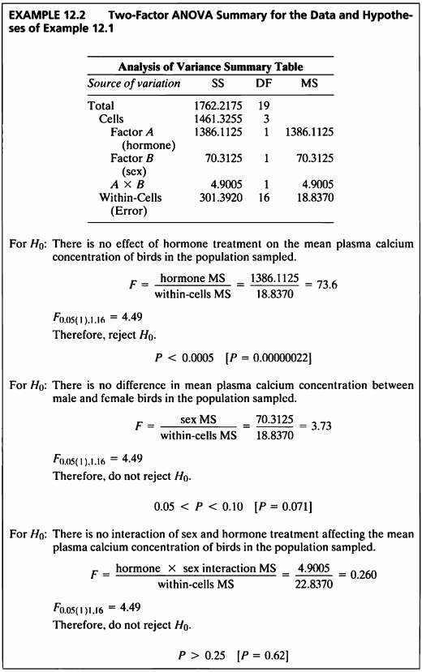

```r
ex12_1$Hormone <- as.factor(ex12_1$exam12_1.Hormone)
ex12_1$Sex <- as.factor(ex12_1$exam12_1.Sex)
```

- 이원분산분석을 진행하기 전에 정규성과 등분산성, 독립성을 만족하는지 부터 확인하도록 한다.

> Shapiro-Wilk Test로 정규성을 평가하였다.

```r
shapiro.test(ex12_1$exam12_1.plasma_calcium)
```

```
##
##  Shapiro-Wilk normality test
##
## data:  ex12_1$exam12_1.plasma_calcium
## W = 0.95332, p-value = 0.4204
```

- p-value가 0.05보다 매우 크므로 모집단이 정규성을 따르지 않는다는 대립가설을 채택할 충분한 근거가 없다.
- 따라서 정규성을 만족한다는 사실을 바탕으로 등분산성 검정을 진행한다.

> Bartlett’s Test를 통해 등분산성 검정을 진행하였다.

```r
bartlett.test(ex12_1$exam12_1.plasma_calcium~ex12_1$exam12_1.Hormone)
```

```
##
##  Bartlett test of homogeneity of variances
##
## data:  ex12_1$exam12_1.plasma_calcium by ex12_1$exam12_1.Hormone
## Bartlett's K-squared = 0.19987, df = 1, p-value = 0.6548
```

```r
bartlett.test(ex12_1$exam12_1.plasma_calcium~ex12_1$exam12_1.Sex)
```

```
##
##  Bartlett test of homogeneity of variances
##
## data:  ex12_1$exam12_1.plasma_calcium by ex12_1$exam12_1.Sex
## Bartlett's K-squared = 0.091482, df = 1, p-value = 0.7623
```

- p-value가 모두 0.05보다 크므로 등분산성이 아니라는 아니라는 대립가설을 채택할 근거가 없다.

> 첫번째 가설

$$\begin{aligned}
H_0 &: There\ is\ no\ effect\ of\ hormone\ treatment\ on\ the\ mean\
plasma\ calcium\ concentration\ of\ birds\ \\
H_A &: There\ is\ an\ effect\ of\ hormone\ treatment\ on\ the\ mean\
plasma\ calcium\ concentration\ of\ birds\ \\
\end{aligned}$$

```r
f12_2_1 <- function(x){
  f <- f12_1a(x)$SS[3]/as.numeric(f12_1a(x)$MS[6])
  f_0.05 <- qf(0.95,1,16)
  p_value <- 1-pf(f,1,16)
  if (f<f_0.05){
    reject_H0 <- "No"
  }else{
    reject_H0 <- "Yes"
  }
  res <- data.frame(f,f_0.05,p_value,reject_H0)
  return(res)
}

f12_2_1(ex12_1a)%>%
  kbl(caption = "Result of hypotheses for Hormone treatment") %>%
  kable_styling(bootstrap_options = c("striped", "hover", "condensed", "responsive"))
```

Result of hypotheses for Hormone treatment

| f | f_0.05 | p_value | reject_H0 |
| --- | --- | --- | --- |
| 73.58457 | 4.493999 | 2e-07 | Yes |

- F-값이 73.6으로 임계값 4.49보다 큰 값이 나왔고, p-value가 0.05보다 매우 작으므로 유의수준 5%하에 귀무가설을 기각한다.
- 따라서 호르몬 치료에 따른 혈청 내 칼슘 함량의 평균이 다르다고 할 수 있다.

> 두번째 가설

$$\begin{aligned}
H_0 &: There\ is\ no\ difference\ \ in\ mean\ plasma\ calcium\
concentration\ between\ female\ and\ male\ birds\ \\
H_A &: There\ is\ a\ difference\ \ in\ mean\ plasma\ calcium\
concentration\ between\ female\ and\ male\ birds\ \\
\end{aligned}$$

```r
f12_2_2 <- function(x){
  f <- f12_1a(x)$SS[4]/as.numeric(f12_1a(x)$MS[6])
  f_0.05 <- qf(0.95,1,16)
  p_value <- 1-pf(f,1,16)
  if (f<f_0.05){
    reject_H0 <- "No"
  }else{
    reject_H0 <- "Yes"
  }
  res <- data.frame(f,f_0.05,p_value,reject_H0)
  return(res)
}

f12_2_2(ex12_1a)%>%
  kbl(caption = "Result of hypotheses for sex") %>%
  kable_styling(bootstrap_options = c("striped", "hover", "condensed", "responsive"))
```

Result of hypotheses for sex

| f | f_0.05 | p_value | reject_H0 |
| --- | --- | --- | --- |
| 3.73268 | 4.493999 | 0.0712638 | No |

- F-값이 3.73으로 임계값 4.49보다 작은 값이 나왔고, p-value가 0.05보다 크므로 유의수준 5%하에 귀무가설을 기각할 수 없다.
- 따라서 성별에 따른 혈청 내 칼슘 함량의 평균이 다르다고 할 수 없다.

> 세번째 가설

$$\begin{aligned}
H_0 &: There\ is\ no\ interaction\ of\ sex\ and\ hormone\ treatment\
on\ the\ mean\ plasma\ calcium\ concentration\ of\ birds\ \\
H_A &: There\ is\ interaction\ of\ sex\ and\ hormone\ treatment\ on\
the\ mean\ plasma\ calcium\ concentration\ of\ birds\ \\
\end{aligned}$$

```r
f12_2_3 <- function(x){
  f <- f12_1a(x)$SS[5]/as.numeric(f12_1a(x)$MS[6])
  f_0.05 <- qf(0.95,1,16)
  p_value <- 1-pf(f,1,16)
  if (f<f_0.05){
    reject_H0 <- "No"
  }else{
    reject_H0 <- "Yes"
  }
  res <- data.frame(f,f_0.05,p_value,reject_H0)
  return(res)
}

f12_2_3(ex12_1a)%>%
  kbl(caption = "Result of hypotheses for interaction") %>%
  kable_styling(bootstrap_options = c("striped", "hover", "condensed", "responsive"))
```

Result of hypotheses for interaction

| f | f_0.05 | p_value | reject_H0 |
| --- | --- | --- | --- |
| 0.2601529 | 4.493999 | 0.6169788 | No |

- F-값이 0.26으로 임계값 4.49보다 작은 값이 나왔고, p-value가 0.05보다 크므로 유의수준 5%하에 귀무가설을 기각할 수 없다.
- 따라서 호르몬과 성별의 교호작용 효과가 있다고 할 수 없다.

> aov()를 사용하여 이원분산분석을 실시한다.

```r
library(broom)
aov(exam12_1.plasma_calcium~exam12_1.Hormone*exam12_1.Sex, data=ex12_1) %>%
  tidy() %>%
  rename(" "="term","Sum Sq"="sumsq","Mean Sq"="meansq","F value"="statistic","Pr(>F)"="p.value") %>%
  kable(caption = "Two-factor ANOVA",booktabs = TRUE, valign = 't')%>%
  kable_styling(bootstrap_options = c("striped", "hover", "condensed", "responsive"))
```

Two-factor ANOVA

|  | df | Sum Sq | Mean Sq | F value | Pr(>F) |
| --- | --- | --- | --- | --- | --- |
| exam12_1.Hormone | 1 | 1386.1125 | 1386.1125 | 73.5845676 | 0.0000002 |
| exam12_1.Sex | 1 | 70.3125 | 70.3125 | 3.7326804 | 0.0712638 |
| exam12_1.Hormone:exam12_1.Sex | 1 | 4.9005 | 4.9005 | 0.2601529 | 0.6169788 |
| Residuals | 16 | 301.3920 | 18.8370 | NA | NA |

> stripchart() 함수로 1차원 산점도를 확인하여 본다.

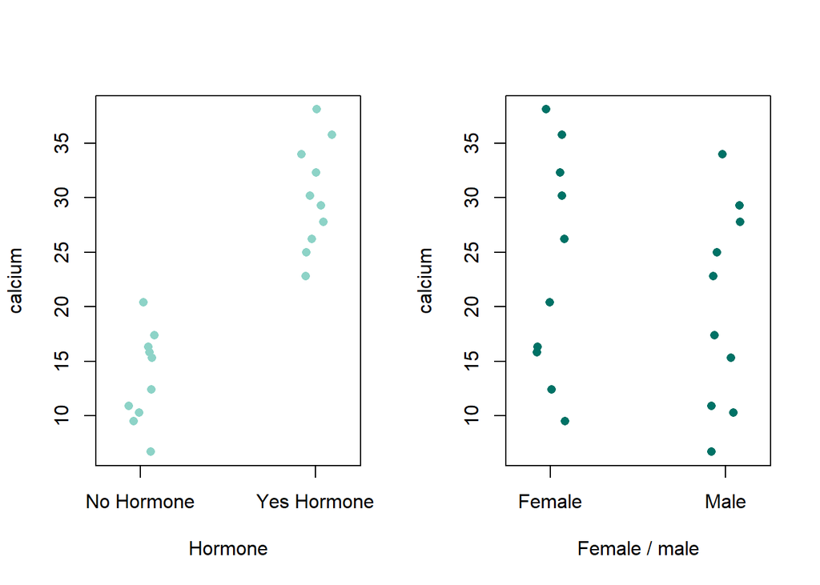

```r
par(mfrow=c(1,2))
stripchart(ex12_1$exam12_1.plasma_calcium~ex12_1$exam12_1.Hormone , vertical=T, xlab="Hormone", ylab="calcium", method="jitter", col="#8dd3c7", pch=16)
stripchart(ex12_1$exam12_1.plasma_calcium~ex12_1$exam12_1.Sex, vertical=T, xlab="Female / male", ylab="calcium", method="jitter", col="#007266", pch=16)
```

- stripchart() 함수는 sample size가 작을 때 box plot을 대신하기 좋다.

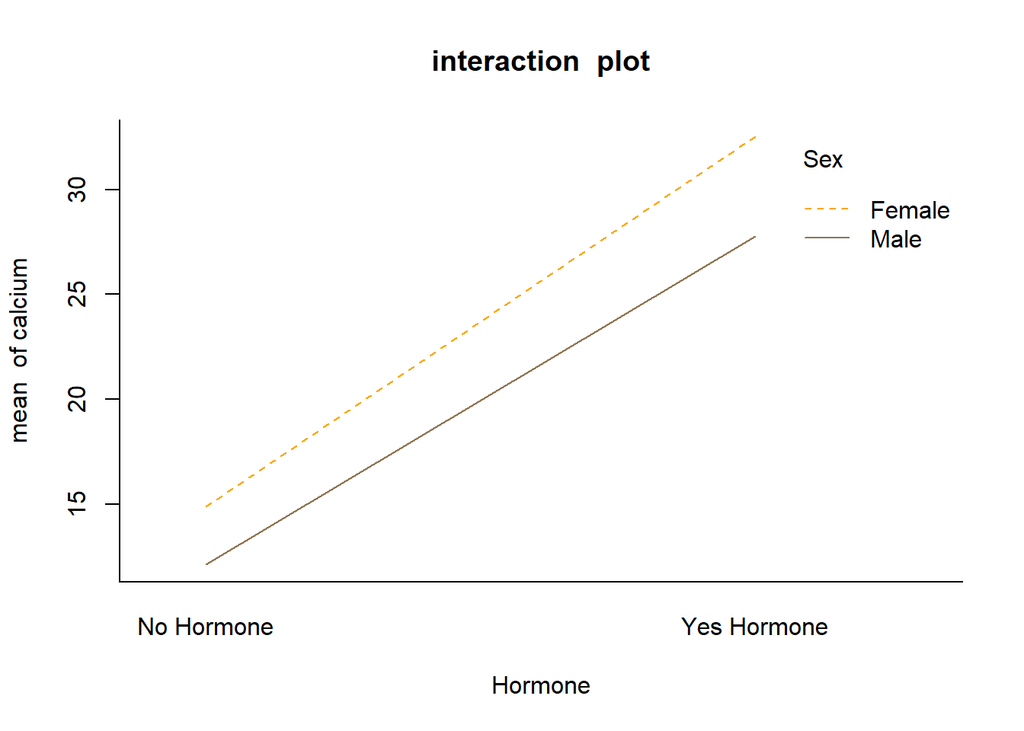

```r
interaction.plot(ex12_1$exam12_1.Hormone,ex12_1$exam12_1.Sex,ex12_1$exam12_1.plasma_calcium, col=c("orange","#8f7450"), bty="l",  main="interaction  plot",  xlab="Hormone",  ylab="mean  of calcium", trace.label = "Sex")
```

- 교호작용 그래프를 보면 서로 겹치는 부분이 없어 성별과 호르몬 간 교호작용이 존재하지 않음을 확인할 수 있으며, 성별이 여자이고 호르몬치료를 받았을 때 혈청 내 칼슘의 농도가 최대가 됨을 알 수 있다.

## 0.5 EXAMPLE 12.2a

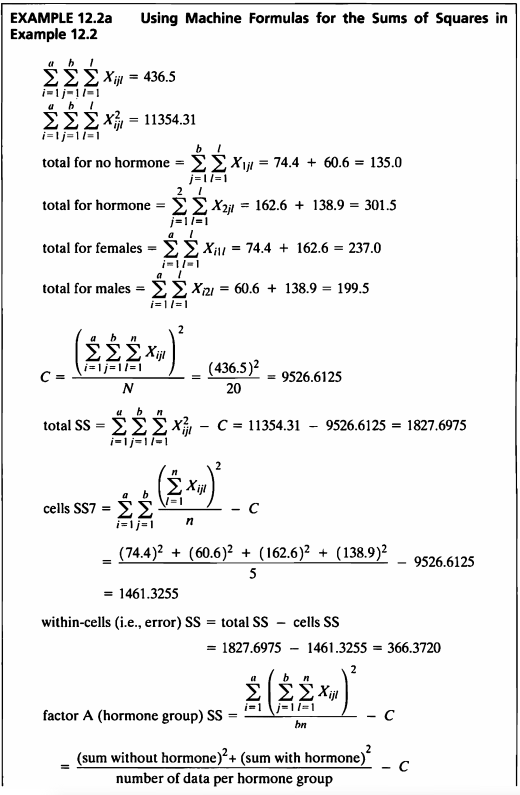

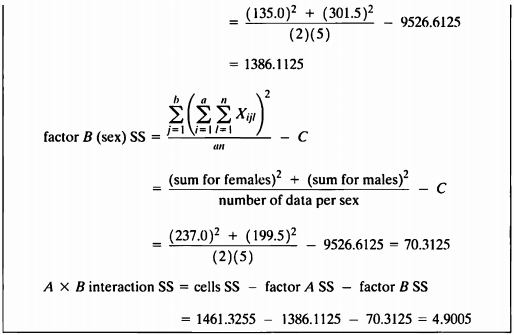

> “Machine Formulas”라는 사용하여 Example 12.1a에서 구한 결과와 같은 값을 구하여 보자.

```r
f12_2a <- function(x){
  N <- (length(x)*nrow(x))
  Xi <- sum(x)
  Xi2 <- sum(x^2)
  C <- sum(x)^2/N
  no_hormone <- sum(x[,1:2])
  hormone <- sum(x[,3:4])
  females <- sum(x[,c(1,3)])
  males <- sum(x[,c(2,4)])
  total_SS <- Xi2-C
  aa <- vector()
  for (i in 1:4){
    aa[i] <- sum(ex12_1a[i])^2
  }
  cells_SS7 <- (sum(aa)/5) -C
  within_cells_SS <- total_SS-cells_SS7
  Factor_A_SS <- ((no_hormone^2+hormone^2)/10)-C
  Factor_B_SS <- ((females^2+males^2)/10)-C
  AXB_interaction_SS <- cells_SS7-Factor_A_SS-Factor_B_SS
  res <- data.frame(total_SS,cells_SS7,within_cells_SS,Factor_A_SS,Factor_B_SS,AXB_interaction_SS)
  return(res)
}

f12_2a(ex12_1a)%>%
  kbl(caption = "Result of Machine formula") %>%
  kable_styling(bootstrap_options = c("striped", "hover", "condensed", "responsive"))
```

Result of Machine formula

| total_SS | cells_SS7 | within_cells_SS | Factor_A_SS | Factor_B_SS | AXB_interaction_SS |
| --- | --- | --- | --- | --- | --- |
| 1762.717 | 1461.325 | 301.392 | 1386.112 | 70.3125 | 4.9005 |

## 0.6 EXAMPLE 12.3

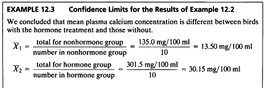

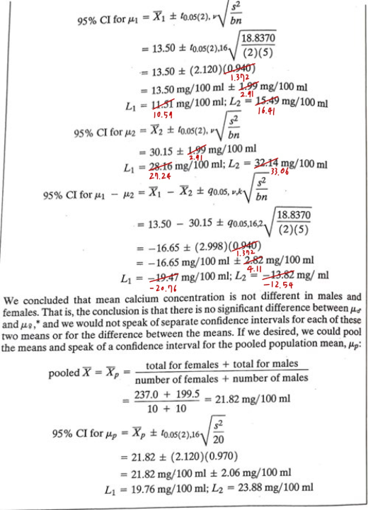

```r
Xbar_1 = mean(ex12_1[ex12_1$exam12_1.Hormone=="No Hormone",]$exam12_1.plasma_calcium)
Xbar_2 = mean(ex12_1[ex12_1$exam12_1.Hormone=="Yes Hormone",]$exam12_1.plasma_calcium)
No.Hormone = ex12_1[ex12_1$exam12_1.Hormone=="No Hormone",]$exam12_1.plasma_calcium
Yes.Hormone = ex12_1[ex12_1$exam12_1.Hormone=="Yes Hormone",]$exam12_1.plasma_calcium
Female=ex12_1[ex12_1$exam12_1.Sex=="Female",]$exam12_1.plasma_calcium
Male=ex12_1[ex12_1$exam12_1.Sex=="Male",]$exam12_1.plasma_calcium
Xbar_pooled = (sum(Female)+sum(Male))/(length(Female)+length(Male))
```

- 호르몬을 처리하지 않은 새들의 plasma calcium 농도의 표본평균은 13.50mg/100ml이고,  
  호르몬을 처리한 새들의 plasma calcium 농도의 표본평균은 30.15 mg/100ml이었다.

```r
CI_ex12 <- function(x){
  exam12_3_results = vector()
  sample.mean <- mean(x)
  exam12_3_results <- c(exam12_3_results, "mean"=sample.mean)
  sample.s2 <- 18.8370
  sample.n <- length(x)
  t.score = round(qt(p=0.05/2, df=16,lower.tail=F),3)
  margin.error <- t.score * sqrt(sample.s2/sample.n)
  lower.bound <- round(sample.mean - margin.error, 2)
  upper.bound <- round(sample.mean + margin.error, 2)
  CI = paste(lower.bound, ",", upper.bound)
  exam12_3_results <- c(exam12_3_results, "95% CI"=CI)
  exam12_3_results <- as.data.frame(exam12_3_results)
  return(exam12_3_results)
}
```

```r
CI_ex12(No.Hormone)
```

```
##        exam12_3_results
## mean               13.5
## 95% CI    10.59 , 16.41
```

```r
CI_ex12(Yes.Hormone)
```

```
##        exam12_3_results
## mean              30.15
## 95% CI    27.24 , 33.06
```

```r
CI_ex12(Female)
```

```
##        exam12_3_results
## mean               23.7
## 95% CI    20.79 , 26.61
```

```r
CI_ex12(Male)
```

```
##        exam12_3_results
## mean              19.95
## 95% CI    17.04 , 22.86
```

- 호르몬을 처리하지 않은 새들의 plasma calcium 농도의 모평균에 대한 95% 신뢰구간 (10.59mg/100ml , 16.41mg/100ml)
- 호르몬 처리를 한 새들의 plasma calcium 농도의 모평균에 대한 95% 신뢰구간 (27.24mg/100ml, 33.06mg/100ml)
- 암컷 새들의 plasma calcium 농도의 모평균에 대한 95% 신뢰구간 (20.79mg/100ml, 26.61mg/100ml)
- 수컷 새들의 plasma calcium 농도의 모평균에 대한 95% 신뢰구간 (17.04mg/100ml, 22.86mg/100ml)

```r
CI_ex12_difference <- function(x){
  exam12_3_results = vector()
  sample.mean <- mean(x)
  exam12_3_results <- c(exam12_3_results, "mean"=sample.mean)
  sample.s2 <- 18.8370
  sample.n <- length(x)
  q.score = round(qtukey(p=0.95,2,16),3)
  margin.error <- q.score * sqrt(sample.s2/sample.n)
  lower.bound <- round(sample.mean - margin.error, 2)
  upper.bound <- round(sample.mean + margin.error, 2)
  CI = paste(lower.bound, ",", upper.bound)
  exam12_3_results <- c(exam12_3_results, "95% CI"=CI)
  exam12_3_results <- as.data.frame(exam12_3_results)
  return(exam12_3_results)
}
```

```r
CI_ex12_difference(No.Hormone - Yes.Hormone)
```

```
##        exam12_3_results
## mean             -16.65
## 95% CI  -20.76 , -12.54
```

```r
CI_ex12_difference(Female - Male)
```

```
##        exam12_3_results
## mean               3.75
## 95% CI     -0.36 , 7.86
```

- 호르몬을 처리하지 않은 새들의 plasma calcium 농도의 모평균과 호르몬 처리를 한 새들의 plasma calcium 농도의 모평균의 차에 대한 95% 신뢰구간 (-20.76mg/100ml, -12.54mg/100ml)
- 신뢰구간이 0을 포함하지 않으므로 유의수준 5%하에 호르몬 처리에 따라 새들의 plasma calcium 농도의 모평균에는 차이가 있다고 볼 수 있다.
- 암컷 새들의 plasma calcium 농도의 모평균과 수컷 새들의 plasma calcium 농도의 모평균의 차에 대한 95% 신뢰구간 (-0.36mg/100ml, 7.86mg/100ml)
- 신뢰구간이 0을 포함하므로, 유의수준 5%하에 plasma calcium 농도의 모평균은 암컷과 수컷 새들 간에 유의미한 차이가 없다고 말할 수 있다.

```r
CI_ex12_pooled <- function(x){
  exam12_3_pooled = vector()
  exam12_3_pooled = c(exam12_3_pooled, "Xbar_pooed"=x)
  t.score = qt(p=0.05/2, df=16,lower.tail=F)
  s2=18.8370
  margin = t.score * sqrt(s2/(length(Female)+length(Male)))
  lower.bound = round(x - margin, 3)
  upper.bound = round(x + margin, 3)
  CI = paste(lower.bound, ",", upper.bound)
  exam12_3_results <- c(exam12_3_pooled, "95% CI"=CI)
  exam12_3_results <- as.data.frame(exam12_3_results)
  return(exam12_3_results)
}
```

```r
CI_ex12_pooled(Xbar_pooled)
```

```
##            exam12_3_results
## Xbar_pooed           21.825
## 95% CI      19.768 , 23.882
```

- pooled population mean에 대한 95% 신뢰구간은 (19.76mg/100ml, 23.88mg/100ml)이다.

## 0.7 EXAMPLE 12.4

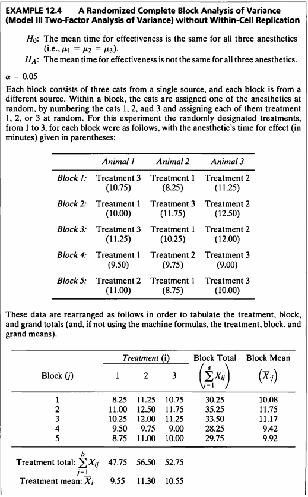

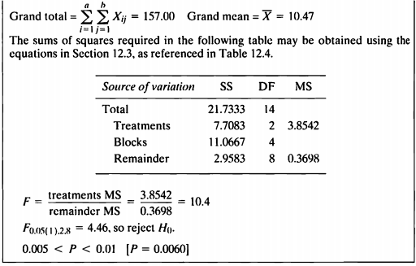

- 해당 데이터는 5개의 블록으로 구성되어 있으며, 한 블록에 세 마리의 고양이로 구성되어있다.  
  한 블록 안에서 고양이들은 세가지 마취제 중 하나를 무작위로 배정받는다.  
  배정받은 마취제의 효과 시간(분)을 기록한 데이터이다.
- 블록 내에 마취제를 투여함에 있어서는 반복을 하지 않으며, 고양이들이 랜덤으로 설정되었으며 이러한 반복이 없는 경우를 난괴법(Randomized Block Design)이라 한다.

```r
#데이터셋
ex12_4%>%
  kbl(caption = "Dataset",escape=F) %>%
  kable_styling(bootstrap_options = c("striped", "hover", "condensed", "responsive"))
```

Dataset

| exam12_4.Treatment | exam12_4.Block | exam12_4.Time |
| --- | --- | --- |
| 1 | 1 | 8.25 |
| 1 | 2 | 11.00 |
| 1 | 3 | 10.25 |
| 1 | 4 | 9.50 |
| 1 | 5 | 8.75 |
| 2 | 1 | 11.25 |
| 2 | 2 | 12.50 |
| 2 | 3 | 12.00 |
| 2 | 4 | 9.75 |
| 2 | 5 | 11.00 |
| 3 | 1 | 10.75 |
| 3 | 2 | 11.75 |
| 3 | 3 | 11.25 |
| 3 | 4 | 9.00 |
| 3 | 5 | 10.00 |

```r
library(ggplot2)
ex12_4$exam12_4.Treatment <- as.factor(ex12_4$exam12_4.Treatment)
ex12_4$exam12_4.Block <- as.factor(ex12_4$exam12_4.Block)
```

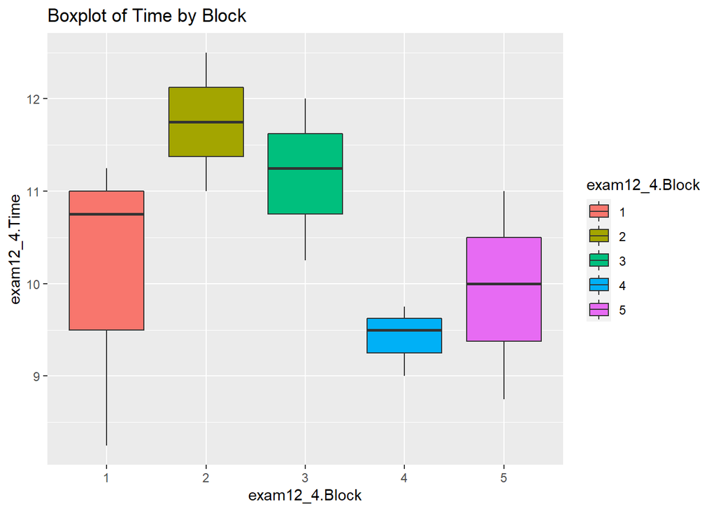

```r
ggplot(ex12_4, aes(x = exam12_4.Block, y = exam12_4.Time, fill=exam12_4.Block)) +
  geom_boxplot()+
  ggtitle("Boxplot of Time by Block")
```

- 블록의 따른 마취 지속효과를 박스플롯으로 확인하여 보았다.

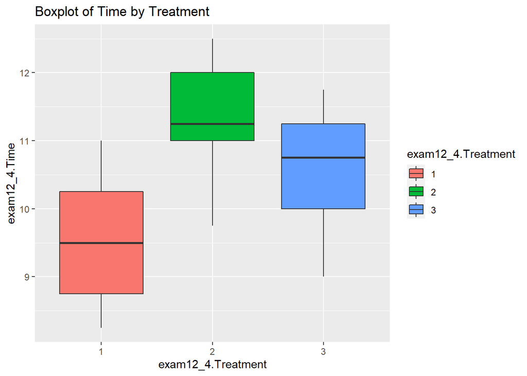

```r
ggplot(ex12_4, aes(x = exam12_4.Treatment, y = exam12_4.Time, fill=exam12_4.Treatment)) +
  geom_boxplot()+
  ggtitle("Boxplot of Time by Treatment")
```

- 마취제의 따른 마취 지속효과를 박스플롯으로 확인하여 보았다.

> Shapiro-Wilk Test로 정규성을 평가하였다.

```r
shapiro.test(ex12_4$exam12_4.Time)
```

```
##
##  Shapiro-Wilk normality test
##
## data:  ex12_4$exam12_4.Time
## W = 0.97427, p-value = 0.9155
```

- p-value가 0.05보다 매우 크므로 모집단이 정규성을 따르지 않는다는 대립가설을 채택할 충분한 근거가 없다.
- 따라서 정규성을 만족한다는 사실을 바탕으로 등분산성 검정을 진행한다.

> Bartlett’s Test를 통해 등분산성 검정을 진행하였다.

```r
bartlett.test(ex12_4$exam12_4.Time~ex12_4$exam12_4.Treatment)
```

```
##
##  Bartlett test of homogeneity of variances
##
## data:  ex12_4$exam12_4.Time by ex12_4$exam12_4.Treatment
## Bartlett's K-squared = 0.01031, df = 2, p-value = 0.9949
```

- p-value가 모두 0.05보다 크므로 등분산성이 아니라는 아니라는 대립가설을 채택할 근거가 없다.
- 본 검정의 가설은 다음과 같다.

$$\begin{aligned}
H_0 &:The\ mean\ time\ for\ effectiveness\ is\ the\ same\ for\ all\
three\ anesthetics. \\
H_1 &: The\ mean\ time\ for\ effectiveness\ is\ not\ the\ same\ for\
all\ three\ anesthetics.
\end{aligned}$$

> Randomized Complete Block ANOVA

```r
aov(exam12_4.Time~exam12_4.Treatment+exam12_4.Block, data = ex12_4) %>%
  tidy() %>%
  rename(" "="term","Sum Sq"="sumsq","Mean Sq"="meansq","F value"="statistic","Pr(>F)"="p.value") %>%
  kable(caption = "Randomized Complete Block ANOVA",booktabs = TRUE, valign = 't') %>%
  kable_styling(bootstrap_options = c("striped", "hover", "condensed", "responsive"))
```

Randomized Complete Block ANOVA

|  | df | Sum Sq | Mean Sq | F value | Pr(>F) |
| --- | --- | --- | --- | --- | --- |
| exam12_4.Treatment | 2 | 7.708333 | 3.8541667 | 10.42254 | 0.0059166 |
| exam12_4.Block | 4 | 11.066667 | 2.7666667 | 7.48169 | 0.0082277 |
| Residuals | 8 | 2.958333 | 0.3697917 | NA | NA |

- 블록이 있는 분산분석을 수행한 결과이다.
- 분산분석 결과를 보면 Treatement와 블록의 p-value는 모두 0.05 보다 작으므로 귀무가설을 기각할 충분한 근거를 가지고 있다.  
  그러므로 마취약에 따라 마취의 효과 시간에 대한 모평균이 다르다라고 할 수 있다.

## 0.8 EXAMPLE 12.5

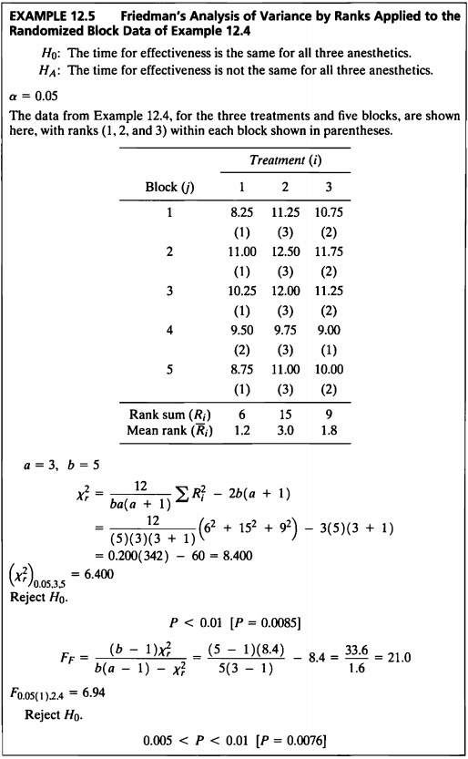

- Example 12.4의 데이터를 사용하여 비모수적 방법인 Friedman’s test를 수행하도록 한다.
- 이 검정 방법은 각 블록 내에 있는 Treatment 즉, 마취제의 효과가 있는 시간에 대한 평균을 가지고 Rank를 매긴다.

> Friedman’s Test

```r
library(agricolae)
fr <- friedman(ex12_4$exam12_4.Block, trt=ex12_4$exam12_4.Treatment, ex12_4$exam12_4.Time, alpha=0.05)
  kable(fr[[1]], caption = paste0("Friedman's Test"))%>%
  kable_styling(bootstrap_options = c("striped", "hover", "condensed", "responsive"));kable(fr[[2]], caption = paste0("Parameters"))%>%
  kable_styling(bootstrap_options = c("striped", "hover", "condensed", "responsive"));kable(fr[[3]], caption = paste0("Means"))%>%
  kable_styling(bootstrap_options = c("striped", "hover", "condensed", "responsive"));kable(fr[[5]], caption = paste0("Post Hoc"))%>%
  kable_styling(bootstrap_options = c("striped", "hover", "condensed", "responsive"))
```

Friedman’s Test

|  | Chisq | Df | p.chisq | F | DFerror | p.F | t.value | LSD |
| --- | --- | --- | --- | --- | --- | --- | --- | --- |
|  | 8.4 | 2 | 0.0149956 | 21 | 8 | 0.0006554 | 2.306004 | 3.261182 |

Parameters

|  | test | name.t | ntr | alpha |
| --- | --- | --- | --- | --- |
|  | Friedman | ex12_4$exam12_4.Treatment | 3 | 0.05 |

Means

| ex12_4.exam12_4.Time | rankSum | std | r | Min | Max | Q25 | Q50 | Q75 |
| --- | --- | --- | --- | --- | --- | --- | --- | --- |
| 9.55 | 6 | 1.109617 | 5 | 8.25 | 11.00 | 8.75 | 9.50 | 10.25 |
| 11.30 | 15 | 1.051784 | 5 | 9.75 | 12.50 | 11.00 | 11.25 | 12.00 |
| 10.55 | 9 | 1.081087 | 5 | 9.00 | 11.75 | 10.00 | 10.75 | 11.25 |

Post Hoc

|  | Sum of ranks | groups |
| --- | --- | --- |
| 2 | 15 | a |
| 3 | 9 | b |
| 1 | 6 | b |

- 본 검정의 귀무가설은 다음과 같다.

$$\begin{aligned}
H_0 &:The\ time\ for\ effectiveness\ is\ the\ same\ for\ all\ three\
anesthetics. \\
H_1 &: The\ time\ for\ effectiveness\ is\ not\ the\ same\ for\ all\
three\ anesthetics.
\end{aligned}$$

```r
pf(as.numeric(fr$statistics[4]),2,4,lower.tail=F)
```

```
## [1] 0.007561437
```

- 프리드만 검정 결과 검정통계량 F값은 21로 나왔으며 p-value=0.0076으로 유의수준 0.05보다 작아 귀무가설을 기각할 충분한 근거를 가진다.  
  따라서 유의수준 5%하에 마취제에 따른 마취시간이 다르다고 할 수 있다.

## 0.9 EXAMPLE 12.6

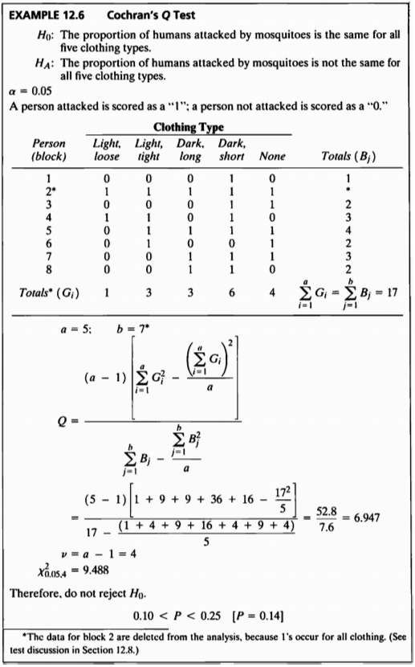

- 본 데이터는 5가지의 옷에 대해 모기에 공격을 당하는지 안당하는지를 기록한 데이터이다.
- Cochran’s Q test는 이항형으로 반복 관측된 데이터에 사용하는 방법으로 이항데이터에 대한 프리드만 검정이라고 할 수 있다.

```r
ex12_6%>%
  kbl(caption = "Dataset of Example 12.2") %>%
  kable_styling(bootstrap_options = c("striped", "hover", "condensed", "responsive"))
```

| exam12_6.Person | exam12_6.Lightloose | exam12_6.Lighttight | exam12_6.Darklong | exam12_6.Darkshort | exam12_6.None |
| --- | --- | --- | --- | --- | --- |
| 1 | 0 | 0 | 0 | 1 | 0 |
| 2 | 1 | 1 | 1 | 1 | 1 |
| 3 | 0 | 0 | 0 | 1 | 1 |
| 4 | 1 | 1 | 0 | 1 | 0 |
| 5 | 0 | 1 | 1 | 1 | 1 |
| 6 | 0 | 1 | 0 | 0 | 1 |
| 7 | 0 | 0 | 1 | 1 | 1 |
| 8 | 0 | 0 | 1 | 1 | 0 |

- 본 검정의 가설은 다음과 같다.

$$\begin{aligned}
H_0 &:The\ proportion\ of\ humans\ attacked\ by\ mosquitoes\ is\
the\ same\ for\ all\ five\ clothing\ types.\\
H_1 &: The\ proportion\ of\ humans\ attacked\ by\ mosquitoes\ is\
not\ the\ same\ for\ all\ five\ clothing\ types.\\ \end{aligned}$$

> Cochran’s Test

```r
library(nonpar)
ex12_6_del <- ex12_6[ex12_6$exam12_6.Person !=2,]
x = ex12_6_del[,-1]
cochrans.q(x)
```

```
##
##  Cochran's Q Test
##
##  H0: There is no difference in the effectiveness of treatments.
##  HA: There is a difference in the effectiveness of treatments.
##
##  Q = 6.94736842105263
##
##  Degrees of Freedom = 4
##
##  Significance Level = 0.05
##  The p-value is  0.138695841622589
##
##
```

- 모든 종류의 옷을 입었을 때 모기에 물린 사람의 데이터는 삭제한다.
- Cochran’s Q Test를 수행한 결과, 검정통계량 값은 6.947, p-value는 0.14로 계산되었다.
- p-value가 0.05보다 크므로, 유의수준 5%하에 모기의 공격을 받은 사람의 비율은 옷의 종류에 따라 차이가 있다고 결론 내릴 수 없다.